# Models

```r
#
#
library(dplyr) #Data Manipulation
library(lme4) #for the model
#
#
```

—————————————- Data —————————————————-

```r
Diversities_BCR <- read.csv("~/Github/Thesis/New data/Diversities_BCR.csv")
```

Diversities if a dataframe with information on the Redudancy (q=0,q=1), Representativeness (q=0,q=1) and Alpha (q=0,q=1) for bird communities data and landscape data for 2504 routes with unique ID Diversities dataframe contains only the routes that had information available for both landcover and bird community data And the BCR for each route (covariate)

```r
head(Diversities_BCR)
```

```
##   X.1 X Unique_State_Route_ID Redundancy_q0 Redundancy_q1 Representativeness_q0
## 1   1 1                02_001      1916.852      1364.789             0.6721239
## 2   2 2                02_004      2028.663      1303.323             0.6199046
## 3   3 3                02_007      1573.520      1110.505             0.6411002
## 4   4 4                02_008      2256.890      1687.910             0.6747601
## 5   5 5                02_010      1994.486      1118.129             0.5575765
## 6   6 6                02_012      2588.998      1302.060             0.5150868
##   Representativeness_q1 Alpha_q0 Alpha_q1 Landscape_Redundancy_q0
## 1             0.4785490       77 41.45099                3206.164
## 2             0.3982604       68 35.86081                3205.557
## 3             0.4524538       74 41.98497                3205.874
## 4             0.5046477       83 45.61877                3205.548
## 5             0.3125829       67 44.85292                3205.546
## 6             0.2590476       68 43.32806                3206.141
##   Landscape_Redundancy_q1 Landscape_Representativeness_q0
## 1                2634.729                       0.9963589
## 2                2355.494                       0.9963589
## 3                2237.752                       0.9963589
## 4                2844.815                       0.9963589
## 5                2477.306                       0.9963589
## 6                2444.827                       0.9963589
##   Landscape_Representativeness_q1 Landscape_Alpha_q0 Landscape_Alpha_q1 BCR
## 1                       0.8187779                 16           5.719717  27
## 2                       0.7321402                 16           5.001746  28
## 3                       0.6954745                 16           4.324046  24
## 4                       0.8842348                 16           5.929676  28
## 5                       0.7700048                 16           4.678451  29
## 6                       0.7597686                 16           4.862512  28
```

```r
landscape_data_buffers_2016 <- read.csv("~/Github/Thesis/New data/landscape_data_buffers_2016.csv")
```

landscape_data_buffers_2016 is a dataframe created on QGIS with the values of each type of landcover in the 23km buffers centred in the centroid of each route present in the Routes_Compiled shapefile. 3229 total routes with a unique ID that matches the ID from Diversities

```r
head(landscape_data_buffers_2016)
```

```
##   U_S_R_I HISTO_0 HISTO_11 HISTO_12 HISTO_21 HISTO_22 HISTO_23 HISTO_24
## 1  02_072       0    76191        0    88416    15306     3224      816
## 2  02_001       0    97679        0   115343    66958    22323     9037
## 3  02_204       0    57445        0    58780    22538     7203     2547
## 4  02_073       0    10581        0    37932    12120     3452     1393
## 5  02_071       0   145826        0   109295    66648    23097     9354
## 6  02_007       0     7773        0    76413    35850     8982     1719
##   HISTO_31 HISTO_41 HISTO_42 HISTO_43 HISTO_52 HISTO_71 HISTO_81 HISTO_82
## 1      438   589285    40888    44969    16652    20971   643723   212534
## 2     3592   555374    74524    78369    69308    34449   409171   203119
## 3     2360   852268    69487   121169    56606    45033   359497   103830
## 4      811  1210700    29152    72154    34324    17757   226587   103452
## 5     1569   321454    59926    59931    24991    27338   438502   385107
## 6      572   992045    25951    59433    30470    19861   318605   185162
##   HISTO_90 HISTO_95
## 1    57799     5207
## 2    70974     5849
## 3    49057     8596
## 4    49022     6975
## 5   131668    11704
## 6    47768     5629
```

Landscape data has more routes than Diversity We need to select the 2504 diversity routes from the landscape data

```r
#
```

not sure what HIST_0 stands for. There is no “0” code in the image file where the other codes were recorded…

```r
Landscape <-  landscape_data_buffers_2016 %>%
  rename("WATER"=3, "ICE"=4, "URBAN_OPEN"=5, "URBAN_LOW"=6,
         "URBAN_MEDIUM"=7, "URBAN_HIGH"=8, "BARREN"=9, "DECIDUOUS_FOREST"=10,
         "EVERGREEN_FOREST"=11,"MIXED_FOREST"=12, "SHRUBLAND"=13,
         "GRASSLAND"=14,"PASTURE"=15, "CROPLAND"=16,"WOODY_WETLAND"=17,
         "HERB_WETLAND"=18) %>%
  mutate(total = rowSums(landscape_data_buffers_2016[, c(3:18)]))

#Change the values of each landcover to proportions

rownames(Landscape)<- Landscape$U_S_R_I
Landscape <- Landscape %>%  select(-U_S_R_I)

Landscape.proportions <- Landscape[,1:17] / Landscape[,18]
Landscape.proportions$U_S_R_I <- rownames(Landscape.proportions)


#Merge the landscape information with the indices dataframe
data <- inner_join(Diversities_BCR, Landscape.proportions, by=c("Unique_State_Route_ID"="U_S_R_I"))
data <- data %>% rename("ID"=X) %>%  select(-X.1)

head(data)
```

```
##   ID Unique_State_Route_ID Redundancy_q0 Redundancy_q1 Representativeness_q0
## 1  1                02_001      1916.852      1364.789             0.6721239
## 2  2                02_004      2028.663      1303.323             0.6199046
## 3  3                02_007      1573.520      1110.505             0.6411002
## 4  4                02_008      2256.890      1687.910             0.6747601
## 5  5                02_010      1994.486      1118.129             0.5575765
## 6  6                02_012      2588.998      1302.060             0.5150868
##   Representativeness_q1 Alpha_q0 Alpha_q1 Landscape_Redundancy_q0
## 1             0.4785490       77 41.45099                3206.164
## 2             0.3982604       68 35.86081                3205.557
## 3             0.4524538       74 41.98497                3205.874
## 4             0.5046477       83 45.61877                3205.548
## 5             0.3125829       67 44.85292                3205.546
## 6             0.2590476       68 43.32806                3206.141
##   Landscape_Redundancy_q1 Landscape_Representativeness_q0
```

[output cut: 34 more lines]

```r
#Changing BCR to a factorial variable
data$BCR <- as.factor(data$BCR)
class(data$BCR)
```

```
## [1] "factor"
```

Histograms

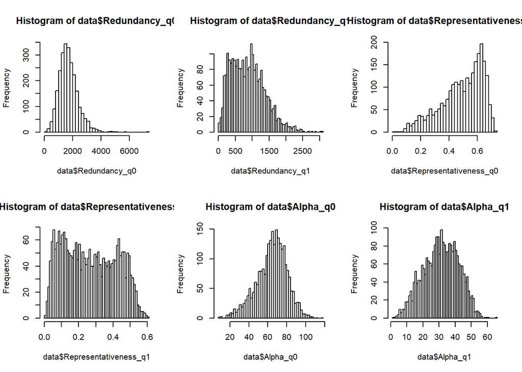

```r
par(mfrow=c(2,3))

hist(data$Redundancy_q0,50)
hist(data$Redundancy_q1,50)
hist(data$Representativeness_q0,50)
hist(data$Representativeness_q1,50)
hist(data$Alpha_q0,50)
hist(data$Alpha_q1,50)
```

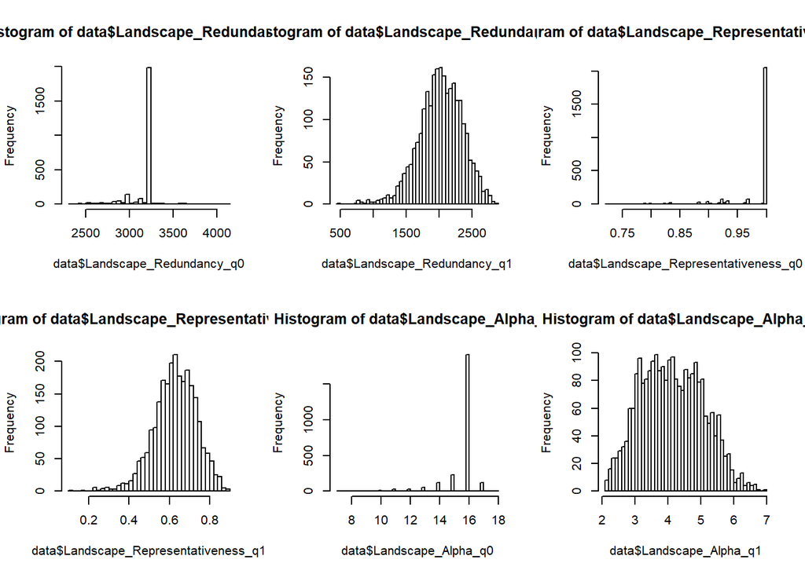

```r
hist(data$Landscape_Redundancy_q0, 50)
hist(data$Landscape_Redundancy_q1, 50)
hist(data$Landscape_Representativeness_q0, 50)
hist(data$Landscape_Representativeness_q1, 50)
hist(data$Landscape_Alpha_q0, 50)
hist(data$Landscape_Alpha_q1, 50)
```

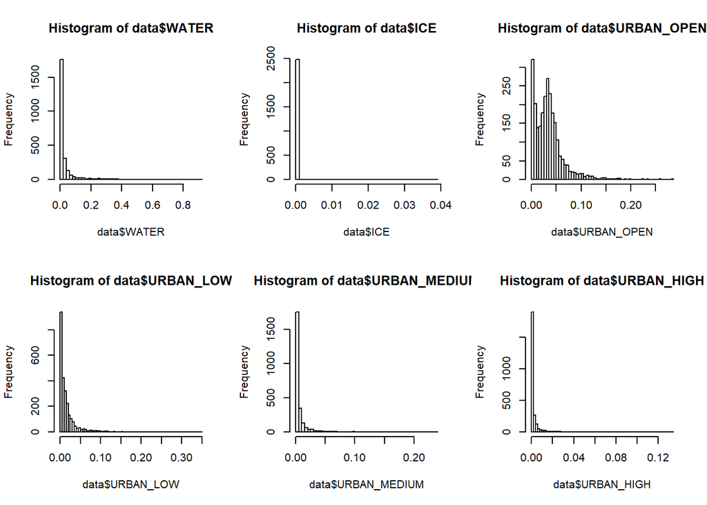

```r
hist(data$WATER, 50)
hist(data$ICE, 50)
hist(data$URBAN_OPEN, 50)
hist(data$URBAN_LOW, 50)
hist(data$URBAN_MEDIUM, 50)
hist(data$URBAN_HIGH, 50)   # Since the survey was performed along secondary roads there might not be a lot of highly urbanised areas around...
```

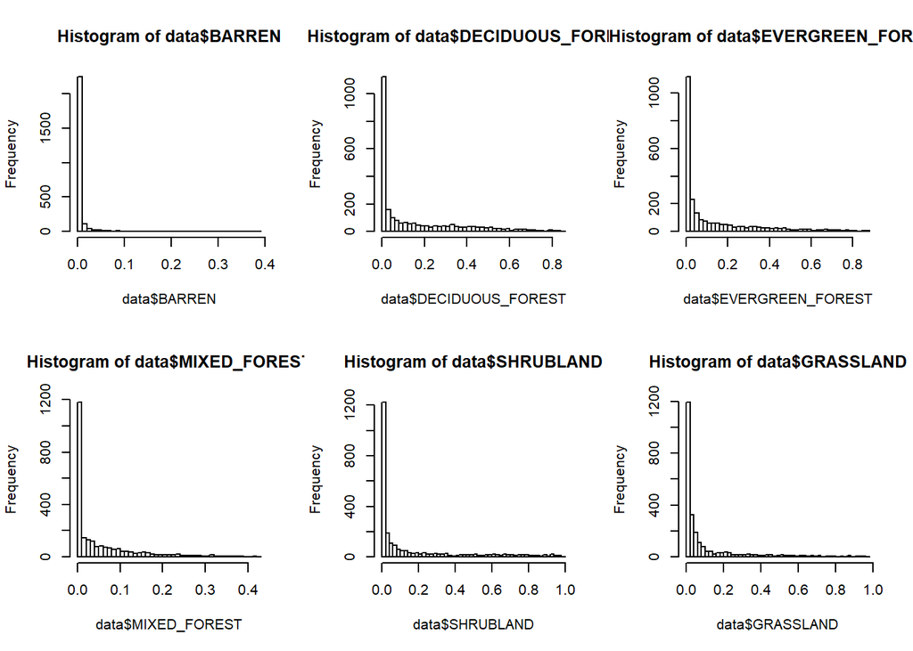

```r
hist(data$BARREN, 50)
hist(data$DECIDUOUS_FOREST, 50)
hist(data$EVERGREEN_FOREST, 50)
hist(data$MIXED_FOREST, 50)
hist(data$SHRUBLAND, 50)
hist(data$GRASSLAND, 50)
```

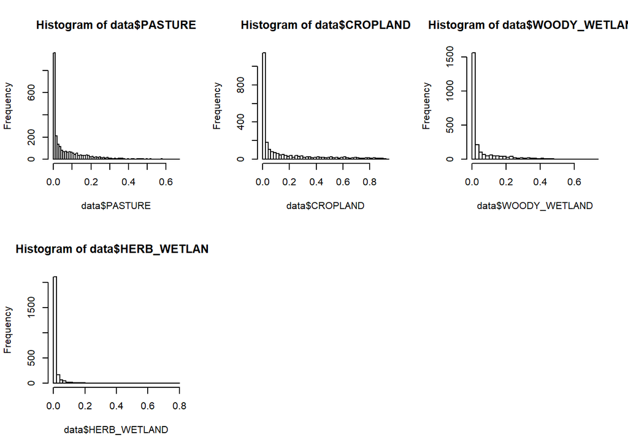

```r
hist(data$PASTURE, 50)
hist(data$CROPLAND, 50)
hist(data$WOODY_WETLAND, 50)
hist(data$HERB_WETLAND, 50)
```

11 - Open Water (WATER)  
12 - Ice/snow (ICE)  
21 - Developed, Open Space (URBAN_OPEN)  
22 - Developed, Low Intensity (URBAN_LOW)  
23 - Developed, Medium Intensity (URBAN_MEDIUM)  
24 - Developed, High Intensity (URBAN_HIGH)  
31 - Barren Land (BARREN)  
41 - Deciduous Forest (DECIDUOUS_FOREST)  
42 - Evergreen Forest (EVERGREEN_FOREST)  
43 - Mixed Forest (MIXED_FOREST)  
52 - Shrub/scrub (SHRUBLAND)  
71 - Grassland/Herbaceous (GRASSLAND)  
81 - Pasture (PASTURE)  
82 - Cultivated Crops (CROPLAND)  
90 - Woody Wetland (WOODY_WETLAND)  
95 - Emergent Herbaceous Wetland (HERB_WETLAND)  
———————————————– MODELS ————————————————–

```r
# REDUNDANCY MODELS ????????
Red.model1 <- glm(Redundancy_q0 ~
                    WATER + ICE +                                                     #
                    URBAN_OPEN + URBAN_LOW + URBAN_MEDIUM + URBAN_HIGH+               # urbans
                    BARREN + DECIDUOUS_FOREST + EVERGREEN_FOREST + MIXED_FOREST +     # forests
                    SHRUBLAND + GRASSLAND + PASTURE + CROPLAND +                      #
                    WOODY_WETLAND + HERB_WETLAND +                                    #
                    Landscape_Redundancy_q0+I(Landscape_Redundancy_q0^2)+             # landscape indices with quadratic term
                    Landscape_Redundancy_q1 + I(Landscape_Redundancy_q1^2) +          #
                    Landscape_Alpha_q0 + I(Landscape_Alpha_q0^2) +                    #
                    Landscape_Alpha_q1 + I(Landscape_Alpha_q1^2) +                    #
                    Alpha_q0 + Alpha_q1 +                                             # bird alpha diversities
                    BCR,                                                              # observation as random effect?
                    family = gaussian, data=data)                                     #
summary(Red.model1)
```

```
##
## Call:
## glm(formula = Redundancy_q0 ~ WATER + ICE + URBAN_OPEN + URBAN_LOW +
##     URBAN_MEDIUM + URBAN_HIGH + BARREN + DECIDUOUS_FOREST + EVERGREEN_FOREST +
##     MIXED_FOREST + SHRUBLAND + GRASSLAND + PASTURE + CROPLAND +
##     WOODY_WETLAND + HERB_WETLAND + Landscape_Redundancy_q0 +
##     I(Landscape_Redundancy_q0^2) + Landscape_Redundancy_q1 +
##     I(Landscape_Redundancy_q1^2) + Landscape_Alpha_q0 + I(Landscape_Alpha_q0^2) +
##     Landscape_Alpha_q1 + I(Landscape_Alpha_q1^2) + Alpha_q0 +
##     Alpha_q1 + BCR, family = gaussian, data = data)
##
## Deviance Residuals:
##     Min       1Q   Median       3Q      Max
## -1925.3   -319.1    -50.8    254.3   4761.7
##
## Coefficients: (1 not defined because of singularities)
##                                Estimate Std. Error t value Pr(>|t|)
## (Intercept)                   2.570e+03  2.446e+03   1.050 0.293672
## WATER                        -5.084e+02  3.617e+02  -1.406 0.159969
## ICE                          -2.223e+04  8.541e+03  -2.602 0.009320 **
## URBAN_OPEN                    2.991e+01  8.451e+02   0.035 0.971772
## URBAN_LOW                    -1.040e+03  1.290e+03  -0.806 0.420218
## URBAN_MEDIUM                  3.408e+03  2.617e+03   1.302 0.192925
## URBAN_HIGH                   -5.456e+03  5.615e+03  -0.972 0.331344
## BARREN                        8.029e+02  5.733e+02   1.401 0.161472
## DECIDUOUS_FOREST             -9.599e+02  4.801e+02  -1.999 0.045675 *
## EVERGREEN_FOREST             -1.496e+03  4.596e+02  -3.254 0.001152 **
## MIXED_FOREST                 -6.442e+02  4.118e+02  -1.564 0.117895
## SHRUBLAND                    -1.093e+03  4.998e+02  -2.187 0.028847 *
## GRASSLAND                    -8.600e+02  4.407e+02  -1.951 0.051119 .
## PASTURE                      -9.289e+02  4.096e+02  -2.268 0.023418 *
## CROPLAND                     -1.229e+03  4.858e+02  -2.529 0.011505 *
## WOODY_WETLAND                -5.854e+02  4.146e+02  -1.412 0.158131
## HERB_WETLAND                         NA         NA      NA       NA
## Landscape_Redundancy_q0       3.470e-01  1.712e+00   0.203 0.839445
## I(Landscape_Redundancy_q0^2)  3.844e-05  2.829e-04   0.136 0.891940
## Landscape_Redundancy_q1       9.656e-01  4.771e-01   2.024 0.043082 *
## I(Landscape_Redundancy_q1^2) -6.709e-05  9.130e-05  -0.735 0.462489
## Landscape_Alpha_q0           -8.529e+01  1.420e+02  -0.601 0.548192
## I(Landscape_Alpha_q0^2)       3.085e+00  5.050e+00   0.611 0.541307
```

[output cut: 28 more lines]

```
## BCR33                        -5.623e+01  1.235e+02  -0.455 0.648975
## BCR34                        -1.720e+02  1.255e+02  -1.370 0.170739
## BCR35                        -2.067e+02  1.204e+02  -1.717 0.086085 .
## BCR36                        -2.874e+02  1.921e+02  -1.496 0.134728
## BCR37                        -6.537e+01  1.437e+02  -0.455 0.649163
## ---
## Signif. codes:  0 '***' 0.001 '**' 0.01 '*' 0.05 '.' 0.1 ' ' 1
##
## (Dispersion parameter for gaussian family taken to be 266917.9)
##
##     Null deviance: 1111302275  on 2503  degrees of freedom
## Residual deviance:  653681832  on 2449  degrees of freedom
## AIC: 38449
##
## Number of Fisher Scoring iterations: 2
```

```r
sum(is.na(data$HERB_WETLAND))
```

```
## [1] 0
```